# Balu-ml-assignment1

**1. Data Preprocessing:**

• Load the dataset and print a sample number of rows.

• Find the number of rows with any missing values. Remove any row with a missing value.

• Convert 'Gender', 'Smoker', and 'Region' into numerical values suitable for regression analysis (e.g., using one-hot encoding for 'region' and binary encoding for 'sex' and 'smoker').

• Normalize the features using Min-Max scaling.

```python
#1Import libraries numpy, pandas, matplotlib.pyplot
import numpy as np
import matplotlib.pyplot as plt
import pandas as pd
#2 Read the csv file: "insurance.csv"
df = pd.read_csv("insurance.csv")   # data is stored in a dataframe "df"
df
```

|  | Age | Gender | BMI | Children | Smoker | Region | Expenses |
| --- | --- | --- | --- | --- | --- | --- | --- |
| 0 | 19 | female | 27.9 | 0 | yes | southwest | 16884.92 |
| 1 | 18 | male | 33.8 | 1 | no | southeast | 1725.55 |
| 2 | 28 | male | 33.0 | 3 | no | southeast | 4449.46 |
| 3 | 33 | male | 22.7 | 0 | no | northwest | 21984.47 |
| 4 | 32 | male | 28.9 | 0 | no | northwest | 3866.86 |
| ... | ... | ... | ... | ... | ... | ... | ... |
| 1333 | 50 | male | 31.0 | 3 | no | northwest | 10600.55 |
| 1334 | 18 | NaN | 31.9 | 0 | no | northeast | 2205.98 |
| 1335 | 18 | female | NaN | 0 | no | southeast | 1629.83 |
| 1336 | 21 | female | 25.8 | 0 | no | southwest | 2007.95 |
| 1337 | 61 | female | 29.1 | 0 | yes | northwest | 29141.36 |

1338 rows × 7 columns

```python
import numpy as np
import matplotlib.pyplot as plt
import pandas as pd

# Load the dataset and print a sample number of rows
df = pd.read_csv("insurance.csv")
print("Sample data:")
print(df.head())

# Find the number of rows with any missing values and remove them
print("\nNumber of rows with missing values:", df.isnull().any(axis=1).sum())
df.dropna(inplace=True)

# Convert 'Gender', 'Smoker', and 'Region' into numerical values
df['Gender'] = df['Gender'].map({'female': 0, 'male': 1})
df['Smoker'] = df['Smoker'].map({'no': 0, 'yes': 1})
# one hot encoding for region column
df = pd.get_dummies(df, columns=['Region'])

# Normalize the features using Min-Max scaling
from sklearn.preprocessing import MinMaxScaler
scaler = MinMaxScaler()
df[['Age', 'BMI', 'Children', 'Expenses']] = scaler.fit_transform(df[['Age', 'BMI', 'Children', 'Expenses']])

print("\nPreprocessed data:")
print(df.head())
df
```

```
Sample data:
   Age  Gender   BMI  Children Smoker     Region  Expenses
0   19  female  27.9         0    yes  southwest  16884.92
1   18    male  33.8         1     no  southeast   1725.55
2   28    male  33.0         3     no  southeast   4449.46
3   33    male  22.7         0     no  northwest  21984.47
4   32    male  28.9         0     no  northwest   3866.86

Number of rows with missing values: 17

Preprocessed data:
        Age  Gender       BMI  Children  Smoker  Expenses  Region_northeast  \
0  0.021739       0  0.320755  0.481481       1  0.251611                 0
1  0.000000       1  0.479784  0.488889       0  0.009636                 0
2  0.217391       1  0.458221  0.503704       0  0.053115                 0
3  0.326087       1  0.180593  0.481481       0  0.333010                 0
4  0.304348       1  0.347709  0.481481       0  0.043816                 0

   Region_northwest  Region_southeast  Region_southwest
0                 0                 0                 1
1                 0                 1                 0
2                 0                 1                 0
3                 1                 0                 0
4                 1                 0                 0
```

|  | Age | Gender | BMI | Children | Smoker | Expenses | Region_northeast | Region_northwest | Region_southeast | Region_southwest |
| --- | --- | --- | --- | --- | --- | --- | --- | --- | --- | --- |
| 0 | 0.021739 | 0 | 0.320755 | 0.481481 | 1 | 0.251611 | 0 | 0 | 0 | 1 |
| 1 | 0.000000 | 1 | 0.479784 | 0.488889 | 0 | 0.009636 | 0 | 0 | 1 | 0 |
| 2 | 0.217391 | 1 | 0.458221 | 0.503704 | 0 | 0.053115 | 0 | 0 | 1 | 0 |
| 3 | 0.326087 | 1 | 0.180593 | 0.481481 | 0 | 0.333010 | 0 | 1 | 0 | 0 |
| 4 | 0.304348 | 1 | 0.347709 | 0.481481 | 0 | 0.043816 | 0 | 1 | 0 | 0 |
| ... | ... | ... | ... | ... | ... | ... | ... | ... | ... | ... |
| 1331 | 0.108696 | 0 | 0.469003 | 0.481481 | 0 | 0.154418 | 0 | 0 | 0 | 1 |
| 1332 | 0.739130 | 0 | 0.773585 | 0.503704 | 0 | 0.164247 | 0 | 0 | 0 | 1 |
| 1333 | 0.695652 | 1 | 0.404313 | 0.503704 | 0 | 0.151299 | 0 | 1 | 0 | 0 |
| 1336 | 0.065217 | 0 | 0.264151 | 0.481481 | 0 | 0.014144 | 0 | 0 | 0 | 1 |
| 1337 | 0.934783 | 0 | 0.353100 | 0.481481 | 1 | 0.447249 | 0 | 1 | 0 | 0 |

1321 rows × 10 columns

**2. Splitting the Data:**

• Divide the data into “features” and “target” subsets.

• Split the data into training and testing subsets (commonly a 70/30, 75/25, or 80/20 split).

```python
from sklearn.model_selection import train_test_split

# Separate features and target variable
X = df.drop(columns=['Expenses'])  # Features (all columns except 'Expenses')
y = df['Expenses']  # Target variable ('Expenses')

# Split the data into training and testing sets (80/20 split)
X_train, X_test, y_train, y_test = train_test_split(X, y, test_size=0.2, random_state=42)

# Print the shapes of the training and testing sets
print("Shape of X_train:", X_train.shape)
print("Shape of X_test:", X_test.shape)
print("Shape of y_train:", y_train.shape)
print("Shape of y_test:", y_test.shape)
```

```
Shape of X_train: (1056, 9)
Shape of X_test: (265, 9)
Shape of y_train: (1056,)
Shape of y_test: (265,)
```

**3. Gradient Descent Implementation:**

• Implement the gradient descent algorithm (without the Scikit-Learn library) to find the regression line. Initialize parameters randomly and update them iteratively to minimize the loss function. Record the loss value for each iteration:

```
Coefficients: [[ 0.19895498]
 [-0.00502665]
 [ 0.1876389 ]
 [ 1.18748046]
 [ 0.37942189]
 [ 0.42480444]
 [ 0.41989921]
 [ 0.40464794]
 [ 0.40618762]]
Intercept: [-1.04346142]
```

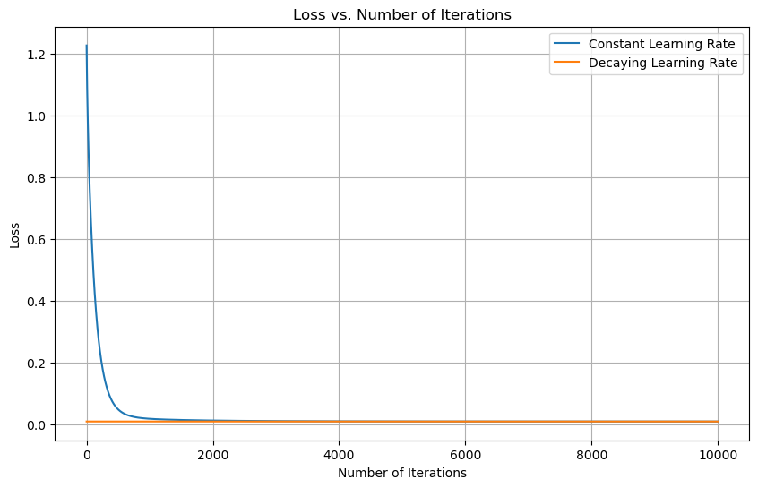

```python
import numpy as np
import matplotlib.pyplot as plt
from sklearn.metrics import mean_squared_error

# Initialize parameters
X_b = np.c_[np.ones((X_train.shape[0], 1)), X_train]
m = X_train.shape[0]  # number of data points
n = X_train.shape[1]  # number of features

n_iterations = 10000   # Number of iterations
W = np.random.randn(n + 1, 1)  # Weight matrix

# Gradient descent with constant learning rate
alpha = 0.01                  # Learning rate
loss_constant_lr = []         # Loss value for each iteration

for iteration in range(n_iterations):
    gradients = 2/m * X_b.T.dot(X_b.dot(W) - y_train.values.reshape(-1, 1))  # Convert y_train to 2D array
    W = W - alpha * gradients
    predictions = X_b.dot(W)
    loss_constant_lr.append(mean_squared_error(y_train, predictions))

# Gradient descent with decaying learning rate
alpha = 0.01                  # Initial learning rate
loss_decaying_lr = []         # Loss value for each iteration

for iteration in range(n_iterations):
    gradients = 2/m * X_b.T.dot(X_b.dot(W) - y_train.values.reshape(-1, 1))  # Convert y_train to 2D array
    alpha = alpha / (1 + iteration * 0.001)  # Exponential decay of learning rate
    W = W - alpha * gradients
    predictions = X_b.dot(W)
    loss_decaying_lr.append(mean_squared_error(y_train, predictions))

# Show the coefficients and intercept of the model
print("Coefficients:", W[1:])
print("Intercept:", W[0])

# Plot the loss values as a function of the number of iterations
plt.figure(figsize=(10, 6))
plt.plot(range(n_iterations), loss_constant_lr, label='Constant Learning Rate')
plt.plot(range(n_iterations), loss_decaying_lr, label='Decaying Learning Rate')
plt.title('Loss vs. Number of Iterations')
plt.xlabel('Number of Iterations')
plt.ylabel('Loss')
plt.legend()
plt.grid(True)
plt.show()
```

**4. Model Evaluation:**

• Predict the expenses for the testing dataset using the trained model.

• Compute the Mean Absolute Error (MAE) and Mean Squared Error (MSE) of the predictions.

• Plot a histogram of the error distribution.

```
Mean Absolute Error (MAE) on Test Set: 0.07521711802788413
Mean Squared Error (MSE) on Test Set: 0.012258436909509366
```

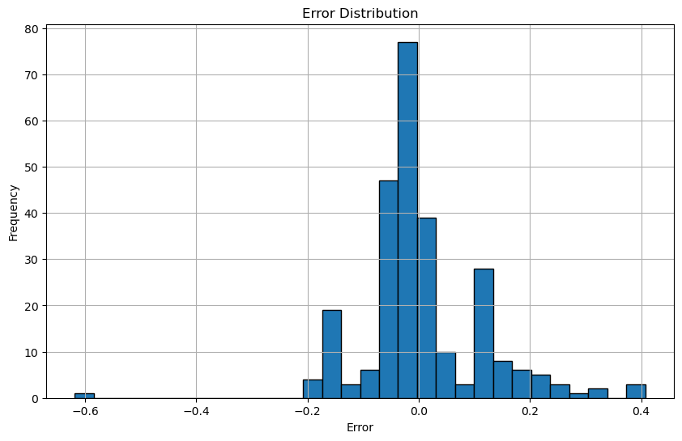

```python
from sklearn.metrics import mean_absolute_error

# Predict expenses for the testing dataset
X_test_b = np.c_[np.ones((X_test.shape[0], 1)), X_test]
y_pred_test = X_test_b.dot(W)

# Compute Mean Absolute Error (MAE) and Mean Squared Error (MSE)
mae_test = mean_absolute_error(y_test, y_pred_test)
mse_test = mean_squared_error(y_test, y_pred_test)

print("Mean Absolute Error (MAE) on Test Set:", mae_test)
print("Mean Squared Error (MSE) on Test Set:", mse_test)

# Plot histogram of error distribution
error = y_test - y_pred_test.flatten()
plt.figure(figsize=(10, 6))
plt.hist(error, bins=30, edgecolor='black')
plt.title('Error Distribution')
plt.xlabel('Error')
plt.ylabel('Frequency')
plt.grid(True)
plt.show()
```

**5. Learning Rate Analysis:**

• Demonstrate the effect of varying the learning rate on the convergence of the gradient descent algorithm.

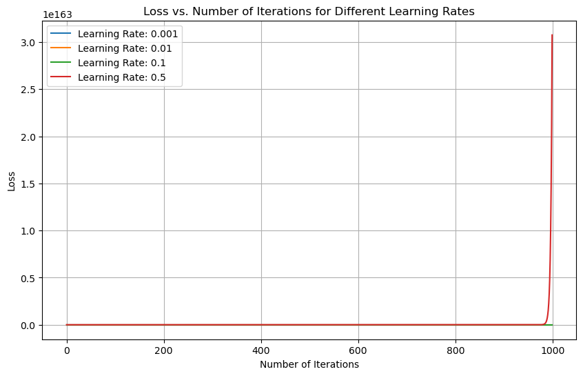

```python
import numpy as np
import matplotlib.pyplot as plt
from sklearn.metrics import mean_squared_error

# Initialize parameters
X_b = np.c_[np.ones((X_train.shape[0], 1)), X_train]
m = X_train.shape[0]  # number of data points
n = X_train.shape[1]  # number of features

n_iterations = 1000   # Number of iterations
learning_rates = [0.001, 0.01, 0.1, 0.5]  # List of learning rates
losses = []

# Gradient descent with varying learning rates
for alpha in learning_rates:
    W = np.random.randn(n + 1, 1)  # Weight matrix
    loss_lr = []  # Loss value for each iteration

    for iteration in range(n_iterations):
        gradients = 2/m * X_b.T.dot(X_b.dot(W) - y_train.values.reshape(-1, 1))
        W = W - alpha * gradients
        predictions = X_b.dot(W)
        loss_lr.append(mean_squared_error(y_train, predictions))

    losses.append(loss_lr)

# Plot the loss values as a function of the number of iterations for each learning rate
plt.figure(figsize=(10, 6))
for i, alpha in enumerate(learning_rates):
    plt.plot(range(n_iterations), losses[i], label=f'Learning Rate: {alpha}')
plt.title('Loss vs. Number of Iterations for Different Learning Rates')
plt.xlabel('Number of Iterations')
plt.ylabel('Loss')
plt.legend()
plt.grid(True)
plt.show()
```

**6. Scikit-learn Implementation:**

• Repeat the regression using the linear_model.LinearRegression class from scikit-learn.

• Compute MAE and MSE for comparison.

```
Scikit-learn Linear Regression:
Mean Absolute Error (MAE): 0.07322090456300624
Mean Squared Error (MSE): 0.010997654911521059
```

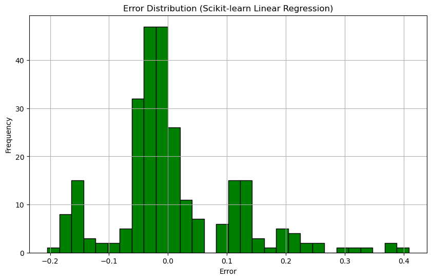

```python
from sklearn.linear_model import LinearRegression
from sklearn.metrics import mean_absolute_error, mean_squared_error

# Create a LinearRegression model
linear_reg = LinearRegression()

# Fit the model to the training data
linear_reg.fit(X_train, y_train)

# Predict expenses for the testing dataset
y_pred_sklearn = linear_reg.predict(X_test)

# Compute Mean Absolute Error (MAE) and Mean Squared Error (MSE)
mae_sklearn = mean_absolute_error(y_test, y_pred_sklearn)
mse_sklearn = mean_squared_error(y_test, y_pred_sklearn)

print("Scikit-learn Linear Regression:")
print("Mean Absolute Error (MAE):", mae_sklearn)
print("Mean Squared Error (MSE):", mse_sklearn)
# Compute error for Scikit-learn Linear Regression
error_sklearn = y_test - y_pred_sklearn

# Plot histogram of error distribution for Scikit-learn Linear Regression
plt.figure(figsize=(10, 6))
plt.hist(error_sklearn, bins=30, color='green', edgecolor='black')
plt.title('Error Distribution (Scikit-learn Linear Regression)')
plt.xlabel('Error')
plt.ylabel('Frequency')
plt.grid(True)
plt.show()
```

**7. Normal Equation Implementation:**

• Use the normal equation method to find the regression line directly.

• Compare the MAE and MSE with previous methods.

```
Normal Equation Method:
Mean Absolute Error (MAE): 0.32214002388997376
Mean Squared Error (MSE): 0.12970225227440854
```

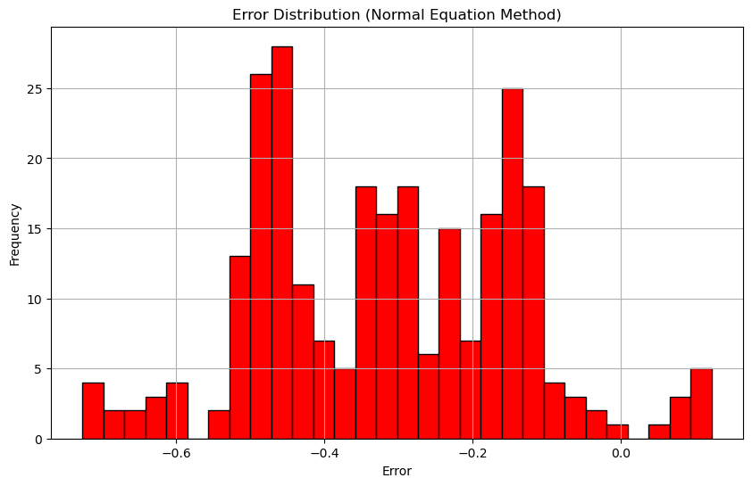

```python
# Adding a bias term to the feature matrix (X_train)
X_train_bias = np.c_[np.ones((X_train.shape[0], 1)), X_train]

# Compute the normal equation to find regression coefficients
theta_normal_eq = np.linalg.inv(X_train_bias.T.dot(X_train_bias)).dot(X_train_bias.T).dot(y_train)

# Predict expenses for the testing dataset using the normal equation coefficients
X_test_bias = np.c_[np.ones((X_test.shape[0], 1)), X_test]
y_pred_normal_eq = X_test_bias.dot(theta_normal_eq)

# Compute Mean Absolute Error (MAE) and Mean Squared Error (MSE) for normal equation method
mae_normal_eq = mean_absolute_error(y_test, y_pred_normal_eq)
mse_normal_eq = mean_squared_error(y_test, y_pred_normal_eq)

print("Normal Equation Method:")
print("Mean Absolute Error (MAE):", mae_normal_eq)
print("Mean Squared Error (MSE):", mse_normal_eq)

# Compute error for Normal Equation Method
error_normal_eq = y_test - y_pred_normal_eq.flatten()

# Plot histogram of error distribution for Normal Equation Method
plt.figure(figsize=(10, 6))
plt.hist(error_normal_eq, bins=30, color='red', edgecolor='black')
plt.title('Error Distribution (Normal Equation Method)')
plt.xlabel('Error')
plt.ylabel('Frequency')
plt.grid(True)
plt.show()
```

**8. Comparison:**

• Compare the three solutions in terms of MAE, MSE, and computational efficiency.

```python
import time

# Gradient Descent
start_time = time.time()
alpha = 0.01
n_iterations = 1000
W = np.random.randn(n + 1, 1)
X_b = np.c_[np.ones((X_train.shape[0], 1)), X_train]
for iteration in range(n_iterations):
    gradients = 2/m * X_b.T.dot(X_b.dot(W) - y_train.values.reshape(-1, 1))
    W = W - alpha * gradients
y_pred_gradient_descent = X_test_b.dot(W)
mae_gradient_descent = mean_absolute_error(y_test, y_pred_gradient_descent)
mse_gradient_descent = mean_squared_error(y_test, y_pred_gradient_descent)
gradient_descent_time = time.time() - start_time

# Scikit-Learn Implementation
start_time = time.time()
linear_reg = LinearRegression()
linear_reg.fit(X_train, y_train)
y_pred_sklearn = linear_reg.predict(X_test)
mae_sklearn = mean_absolute_error(y_test, y_pred_sklearn)
mse_sklearn = mean_squared_error(y_test, y_pred_sklearn)
sklearn_time = time.time() - start_time

# Normal Equation Method
start_time = time.time()
X_train_bias = np.c_[np.ones((X_train.shape[0], 1)), X_train]
theta_normal_eq = np.linalg.inv(X_train_bias.T.dot(X_train_bias)).dot(X_train_bias.T).dot(y_train)
X_test_bias = np.c_[np.ones((X_test.shape[0], 1)), X_test]
y_pred_normal_eq = X_test_bias.dot(theta_normal_eq)
mae_normal_eq = mean_absolute_error(y_test, y_pred_normal_eq)
mse_normal_eq = mean_squared_error(y_test, y_pred_normal_eq)
normal_eq_time = time.time() - start_time

# Print Results
print("Gradient Descent:")
print("MAE:", mae_gradient_descent)
print("MSE:", mse_gradient_descent)
print("Time taken:", gradient_descent_time, "seconds\n")

print("Scikit-Learn Implementation:")
print("MAE:", mae_sklearn)
print("MSE:", mse_sklearn)
print("Time taken:", sklearn_time, "seconds\n")

print("Normal Equation Method:")
print("MAE:", mae_normal_eq)
print("MSE:", mse_normal_eq)
print("Time taken:", normal_eq_time, "seconds")
```

```
Gradient Descent:
MAE: 0.16202521417165403
MSE: 0.042939588072984536
Time taken: 0.014276266098022461 seconds

Scikit-Learn Implementation:
MAE: 0.07322090456300624
MSE: 0.010997654911521059
Time taken: 0.004168272018432617 seconds

Normal Equation Method:
MAE: 0.32214002388997376
MSE: 0.12970225227440854
Time taken: 0.0010001659393310547 seconds
```